# P8105 HW2

Yuchen Zheng

10/6/2021

## Problem 1

Read and clean the Mr. Trash Wheel sheet:

specify the sheet in the Excel file and to omit non-data entries (rows with notes / figures; columns containing notes)

using arguments in read_excel  
use reasonable variable names  
omit rows that do not include dumpster-specific data  
round the number of sports balls to the nearest integer

```r
trash_df =
  read_excel("./data/Trash_Wheel.xlsx", sheet = "Mr. Trash Wheel", range = "A2:N535") %>%
  janitor::clean_names() %>%
  filter(dumpster != "NA") %>%
  mutate(sports_balls = round(sports_balls, digits = 0))
```

Read and clean precipitation data for 2018 and 2019. For each, omit rows without precipitation data and add a variable for year. Next, combine precipitation datasets and convert month to a character variable (the variable month.name is built into R and should be useful).

```r
prcp_2018 =
  read_excel("./data/Trash_Wheel.xlsx", sheet = "2018 Precipitation", skip = 1) %>%
  drop_na() %>%
  mutate(Year = 2018)
```

```r
prcp_2019 =
  read_excel("./data/Trash_Wheel.xlsx", sheet = "2019 Precipitation", skip = 1) %>%
  drop_na() %>%
  mutate(Year = 2019)
```

```r
prcp_combine =
  full_join(prcp_2018, prcp_2019) %>%
  janitor::clean_names() %>%
  mutate(month = month.name[month]) %>%
  relocate(year, month, total)
sports_balls_2019 =
  trash_df %>%
  filter(year == 2019)
```

Write a paragraph about these data; you are encouraged to use inline R. Be sure to note the number of observations in both resulting datasets, and give examples of key variables. For available data, what was the total precipitation in 2018? What was the median number of sports balls in a dumpster in 2019?

The Mr.Trash Wheel dataset contains information about the number of each type of trash collected for each dumpster on a specific date. It contains 454 observations and 14 columns. The columns give the information about total weight and total volume of trash collected on that day. They also give information about the types trash collected which include plastic bottles, cigarette butts, grocery bags, etc. The median number of sports balls in a dumster in 2019 was 9.

The precipitation datasets contain information about the amount of rainfall in each month of a year. Both 2018 and 2019 precipitation datasets have 12 observations and 3 columns. The 2018 and 2019 combined precipitation dataset has 24 observations and 3 columns.

## Problem 2

First, clean the data in pols-month.csv. Use separate() to break up the variable mon into integer variables year, month, and day; replace month number with month name; create a president variable taking values gop and dem, and remove prez_dem and prez_gop; and remove the day variable.

```r
pols_df =
  read_csv("./data/fivethirtyeight_datasets/pols-month.csv") %>%
  separate(mon, into = c("year", "month", "day")) %>%
  mutate(month = as.numeric(month), year = as.numeric(year)) %>%
  mutate(month = month.name[month]) %>%
  mutate(president = ifelse(prez_gop == 0, "dem", "gop")) %>%
  select(-c(prez_dem, prez_gop, day))
```

Second, clean the data in snp.csv using a similar process to the above. For consistency across datasets, arrange according to year and month, and organize so that year and month are the leading columns.

```r
snp_df =
  read_csv("./data/fivethirtyeight_datasets/snp.csv") %>%
  separate(date, into = c("month", "day", "year")) %>%
  mutate(month = as.numeric(month), year = as.numeric(year)) %>%
  mutate(year = ifelse(year < 50, year + 2000, year + 1900)) %>%
  arrange(year, month) %>%
  mutate(month = month.name[month]) %>%
  relocate(year, month)
```

Third, tidy the unemployment data so that it can be merged with the previous datasets. This process will involve switching from “wide” to “long” format; ensuring that key variables have the same name; and ensuring that key variables take the same values.

```r
unemployment_df =
  read_csv("./data/fivethirtyeight_datasets/unemployment.csv") %>%
  rename(year = Year) %>%
  pivot_longer(Jan:Dec, names_to = "month", values_to = "pct_unemploy") %>%
  mutate(month = match(month, month.abb)) %>%
  mutate(month = month.name[month])
```

Join the datasets by merging snp into pols, and merging unemployment into the result.

```r
result =
  left_join(x = pols_df, y = snp_df) %>%
  left_join(unemployment_df)
```

Write a short paragraph about these datasets. Explain briefly what each dataset contained, and describe the resulting dataset (e.g. give the dimension, range of years, and names of key variables).

The pols_df dataset gives the information about the number of politicians who are democratic or republican at a specific month from 1947 to 2015. It has 822 rows and 9 columns. The names of key variables in pols_df dataset are year, month, gov_gop, sen_gop, rep_gop, gov_dem, sen_dem, rep_dem, president.

The snp_df dataset gives the information about the Standard & Poor’s stock market index of a given day from 1950 to 2015. It has 787 rows and 4 columns. The names of key variables in snp_df dataset are year, month, day, close.

The unemployment_df dataset gives the information about the percentage of unemplyment in a given month from 1948 to 2015. It has 816 rows and 3 columns. The names of key variables in unemployment_df dataset are year, month, pct_unemploy.

The resulting dataset contains combined information from the previous datasets, pols_df, snp_df and unemplyment_df. It has 822 observations from 1947 to 2015 and 12 columns. The names of key variables in the resulting dataset are year, month, gov_gop, sen_gop, rep_gop, gov_dem, sen_dem, rep_dem, president, day, close, pct_unemploy.

## Problem 3

Load and tidy the data. Note that, although these data may seem fairly well formatted initially, the names of a categorical predictor and the case structure of string variables changed over time; you’ll need to address this in your data cleaning. Also, some rows seem duplicated, and these will need to be removed (hint: google something like “dplyr remove duplicate rows” to get started).

```r
baby_names_raw =
    read_csv("./data/Popular_Baby_Names.csv") %>%
    janitor::clean_names()
# check count of each ethnicity group
baby_names_raw %>% group_by(ethnicity) %>% summarize(count = n())
```

```
## # A tibble: 7 × 2
##   ethnicity                  count
##   <chr>                      <int>
## 1 ASIAN AND PACI               693
## 2 ASIAN AND PACIFIC ISLANDER  2693
## 3 BLACK NON HISP               681
## 4 BLACK NON HISPANIC          2826
## 5 HISPANIC                    5714
## 6 WHITE NON HISP              1338
## 7 WHITE NON HISPANIC          5473
```

```r
# check count of each name
baby_names_raw %>% group_by(childs_first_name) %>% summarize(count = n())
```

```
## # A tibble: 3,021 × 2
##    childs_first_name count
##    <chr>             <int>
##  1 Aahil                 4
##  2 Aaliyah              12
##  3 AALIYAH               8
##  4 Aarav                 4
##  5 AARAV                 4
##  6 Aaron                24
##  7 AARON                13
##  8 Aarya                 3
##  9 Aaryan                2
## 10 Aayan                 5
## # … with 3,011 more rows
```

```r
baby_names =
  baby_names_raw %>%
  mutate(ethnicity = replace(ethnicity, ethnicity == "ASIAN AND PACI", "ASIAN AND PACIFIC ISLANDER")) %>%
  mutate(ethnicity = replace(ethnicity, ethnicity == "BLACK NON HISP", "BLACK NON HISPANIC")) %>%
  mutate(ethnicity = replace(ethnicity, ethnicity == "WHITE NON HISP", "WHITE NON HISPANIC"))

unique(pull(baby_names, ethnicity))
```

```
## [1] "ASIAN AND PACIFIC ISLANDER" "BLACK NON HISPANIC"
## [3] "HISPANIC"                   "WHITE NON HISPANIC"
```

```r
baby_names = baby_names %>%
  mutate(childs_first_name = tolower(childs_first_name)) %>%
  distinct()
```

Produce a well-structured, reader-friendly table showing the rank in popularity of the name “Olivia” as a female baby name over time; this should have rows for ethnicities and columns for year.

```r
olivia_df =
  baby_names %>%
  filter(childs_first_name == "olivia") %>%
  select(year_of_birth, ethnicity, rank) %>%
  pivot_wider(names_from = "year_of_birth", values_from = "rank") %>%
  relocate(ethnicity, "2011", "2012", "2013", "2014", "2015", "2016")

olivia_df
```

```
## # A tibble: 4 × 7
##   ethnicity                  `2011` `2012` `2013` `2014` `2015` `2016`
##   <chr>                       <dbl>  <dbl>  <dbl>  <dbl>  <dbl>  <dbl>
## 1 ASIAN AND PACIFIC ISLANDER      4      3      3      1      1      1
## 2 BLACK NON HISPANIC             10      8      6      8      4      8
## 3 HISPANIC                       18     22     22     16     16     13
## 4 WHITE NON HISPANIC              2      4      1      1      1      1
```

Produce a similar table showing the most popular name among male children over time.

```r
pop_boy_name =
  baby_names %>%
  filter(gender == "MALE") %>%
  group_by(childs_first_name) %>%
  summarise(total_count = sum(count)) %>%
  arrange(desc(total_count))

head(pop_boy_name)
```

```
## # A tibble: 6 × 2
##   childs_first_name total_count
##   <chr>                   <dbl>
## 1 ethan                    4245
## 2 jacob                    3994
## 3 jayden                   3954
## 4 daniel                   3463
## 5 matthew                  3327
## 6 michael                  3279
```

```r
ethan_df =
  baby_names %>%
  filter(childs_first_name == "ethan") %>%
  select(year_of_birth, ethnicity, rank) %>%
  pivot_wider(names_from = "year_of_birth", values_from = "rank") %>%
  relocate(ethnicity, "2011", "2012", "2013", "2014", "2015", "2016")

ethan_df
```

```
## # A tibble: 4 × 7
##   ethnicity                  `2011` `2012` `2013` `2014` `2015` `2016`
##   <chr>                       <dbl>  <dbl>  <dbl>  <dbl>  <dbl>  <dbl>
## 1 ASIAN AND PACIFIC ISLANDER      1      2      2      2      2      1
## 2 BLACK NON HISPANIC              6      3      1      1      5      5
## 3 HISPANIC                        6      4      5      5      3      7
## 4 WHITE NON HISPANIC             26     21     23     18     19     20
```

Finally, for male, white non-hispanic children born in 2016, produce a scatter plot showing the number of children with a name (y axis) against the rank in popularity of that name (x axis)

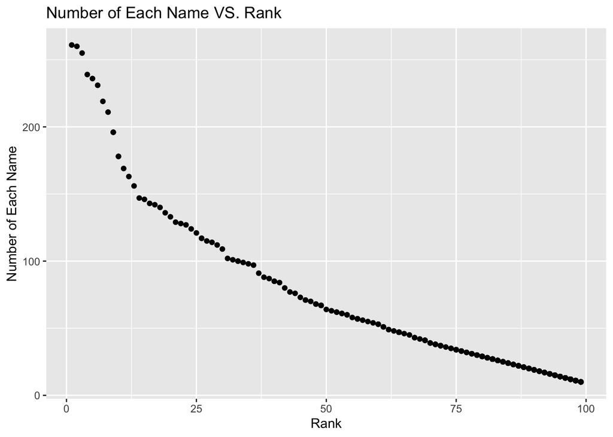

```r
white_2016 =
  baby_names %>%
  filter(ethnicity == "WHITE NON HISPANIC", gender == "MALE", year_of_birth == "2016")

ggplot(white_2016, aes(x = rank, y = count)) +
    geom_point( ) +
    labs(
      title = "Number of Each Name VS. Rank",
      x = "Rank",
      y = "Number of Each Name"
)
```